# Postsecondary and Workforce Readiness Reports

May 04, 2017

2015 Graduates

| District Name | Grad. Rate | % CTE | Avg. ACT | % EPSO | % BHN | % ED | % SWD | % EL |
| --- | --- | --- | --- | --- | --- | --- | --- | --- |
| Hardeman County | 89.8% | 59.5% | 17.7 | 23.3% | 56.7% | 77.3% | 11.7% | 0.81% |

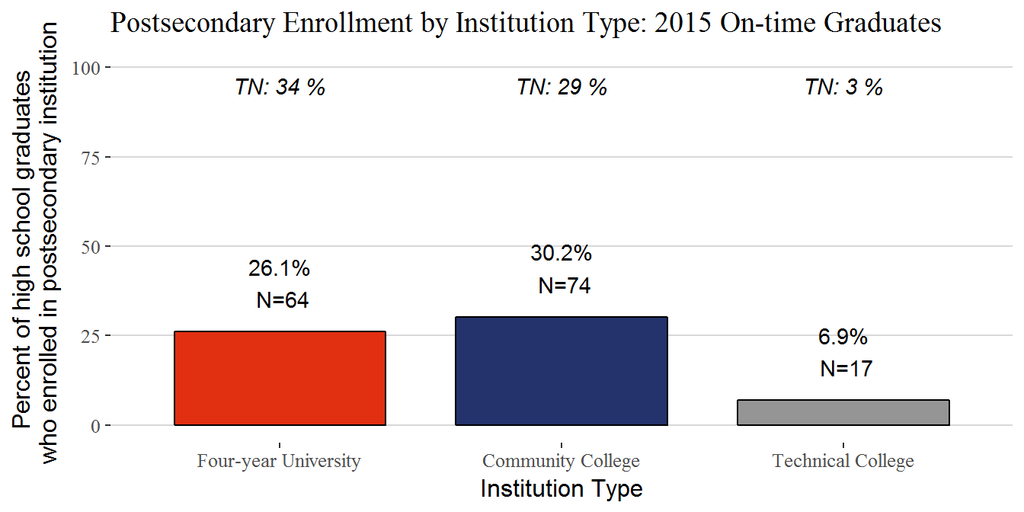

| Institution Name | Number of Enrollees |
| --- | --- |
| Jackson State Community College | 63 |
| Tennessee Technology Center at Whiteville | 17 |
| University of Memphis | 15 |
| Middle Tennessee State University | 12 |
| University of Tennessee, Martin | 7 |

### Definitions

**Graduation Year**: This report uses the term Graduation Year to monitor a cohort of students. This set of graduates would align with the On-Time Graduates with a regular diploma, based on when the group of students entered high school. For example, this report provides data on the 2011 freshman cohort, which is a group of students who entered high school in the fall of 2011. The vast majority of these students graduated in the spring of 2015. The most recent postsecondary enrollment data available is for the 2015 graduates fromn the 2011 freshman cohor.

**Postsecondary Enrollment**: A student is identified as having enrolled in a postsecondary institution if they enroll within 12 months of expectred graduation year for students in the 2011 ninth grade cohort. Eligible institutions include Tennessee Board of Regents’ schools, UT System, Tennessee Colleges of Applied Technology, TICUA institutions, and any non-Tennessee institution that shares enrollment information with the National Student Clearinghouse.

**Postsecondary Remediation**: A student is identified as being assigned to a remedial course if they are designated as having non-zero remedial hours by their postsecondary institution. This information is only available from Tennessee public postsecondary institutions. At this time, the data are not able to be disaggregated at the subject level (e.g. we are unable to see whether a student took a remedial course in English or Math).

**Postsecondary Completion**: Postsecondary completion documentation is shown for students in the 2007 and 2008 ninth grade graduating cohorts, the earliest group of students that the Tennessee Longitudinal Data System can track from secondary into postsecondary. Any degree-granting public institution that submits completion information to THEC is included in this set of data points. For students in the 2007 ninth grade cohort, we display a 5 year completion rate and for students in the 2008 ninth grade cohort, we show a 4 year completion rate. As of May 04, 2017, the most recent term with completion information available is Summer 2016. A student’s most advanced degree is shown.

### District comparisons

For some topics, comparing a school district’s data to statewide trends is not illuminating because the characteristics of the district’s student population are very different from the characteristics of the student population across Tennessee. For ACT and postsecondary enrollment data, this report provides comparisons to Tennessee school districts whose populations share similar demographic characteristics. Be respectful in your use of other school districts’ information; do not share this information publicly.

| Your District | Comparison 1 | Comparison 2 | Comparison 3 | Comparison 4 | Comparison 5 |
| --- | --- | --- | --- | --- | --- |
| Hardeman County | Fayette County | Lauderdale County | Haywood County | Dyersburg City | Jackson-Madison County |

## SECTION I: Postsecondary Enrollment

### Postsecondary Enrollment over time

- What are the general enrollment trends in my district? Have these percentages changed over time?

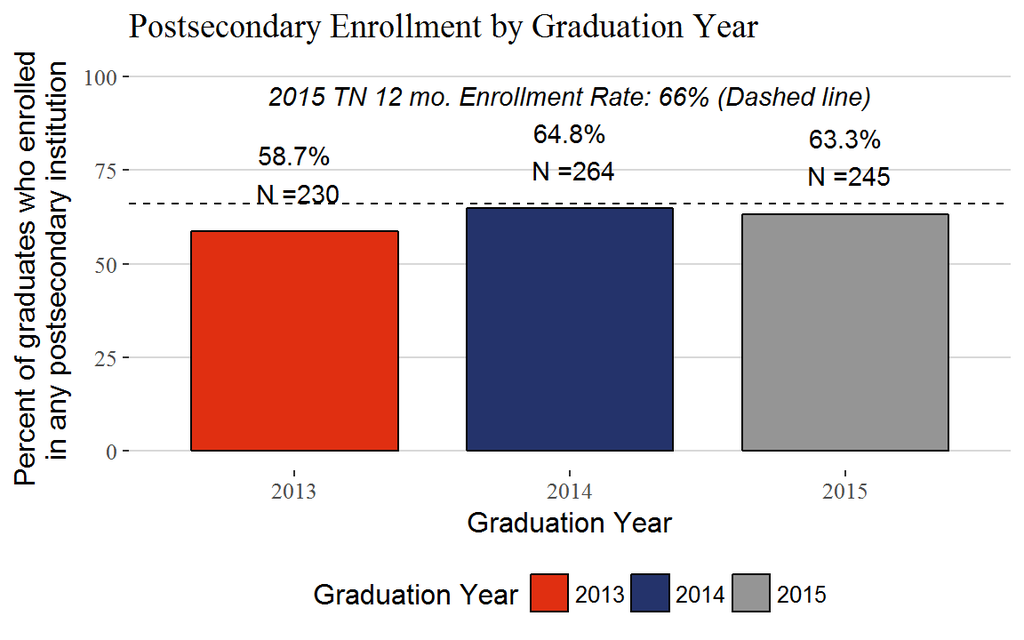

- What type of institutions are my students enrolling in?

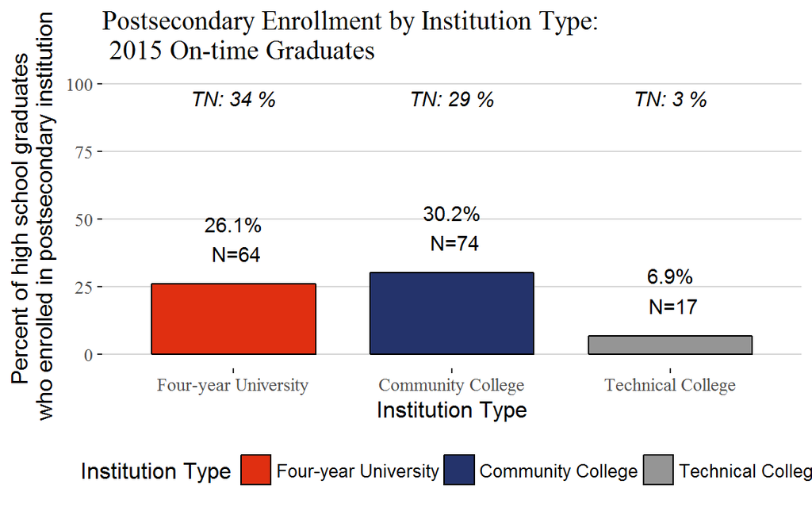

### Most Common Institutions

The following table shows the most common institutions that students from the 2015 graduating class enrolled in within 12 months of graduation.

Consider opportunities for an external partnership with the institution and where students have been successful. Some questions that you may want to consider:

- Are students enrolling in institutions that are nearest to your school?
- Have students taken dual enrollment courses or attended summer programs at these institutions while in high school?
- Are students in your school aware of the majors offered at these institutions?
- Do your programs of study align with opportunities at these institutions?

| Institution Name | Number of Enrollees | Percent of Graduates |
| --- | --- | --- |
| Jackson State Community College | 63 | 25.7 |
| Tennessee Technology Center at Whiteville | 17 | 6.9 |
| University of Memphis | 15 | 6.1 |
| Middle Tennessee State University | 12 | 4.9 |
| University of Tennessee, Martin | 7 | 2.9 |
| Tennessee State University | 6 | 2.4 |
| Mississippi State University | 6 | 2.4 |
| Other Four-year Universities | 18 | 7.3 |
| Other Community Colleges | 11 | 4.5 |

### District Comparisons

- How does the overall enrollment compare to similar districts in terms of overall postsecondary enrollment?
- How does the overall enrollment compare to the state overall enrollment (First and last bars)?
- How does the enrollment into different institution types compare to similar districts in terms of overall postsecondary enrollment?
- How does the enrollment into different institution types compare to the state distribution of enrollment into institution types (First and last bars)?

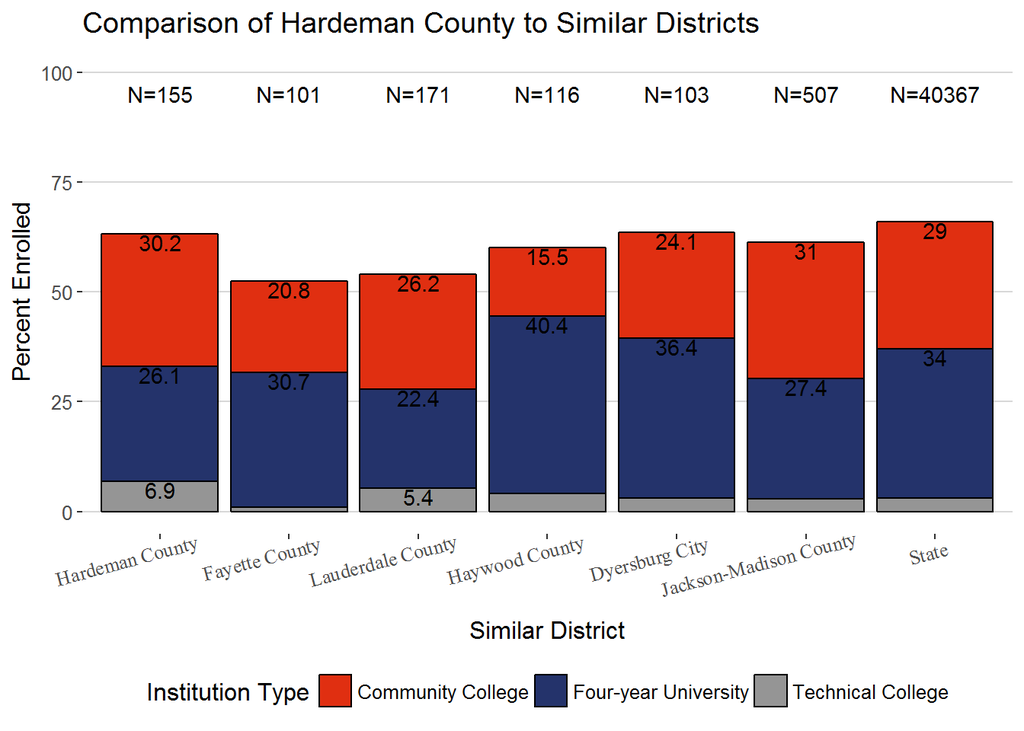

| Similar District | Four-year University | Community College | Technical College |
| --- | --- | --- | --- |
| Hardeman County | 26.1 | 30.2 | 6.9 |
| Fayette County | 30.7 | 20.8 | 1.0 |
| Lauderdale County | 22.4 | 26.2 | 5.4 |
| Haywood County | 40.4 | 15.5 | 4.1 |
| Dyersburg City | 36.4 | 24.1 | 3.1 |
| Jackson-Madison County | 27.4 | 31.0 | 2.9 |
| State | 34.0 | 29.0 | 3.0 |

### School-level Enrollment

- How do the overall enrollment rates differ across schools in my district?
- How does the distribution of students to different institution types compare across schools in my district?

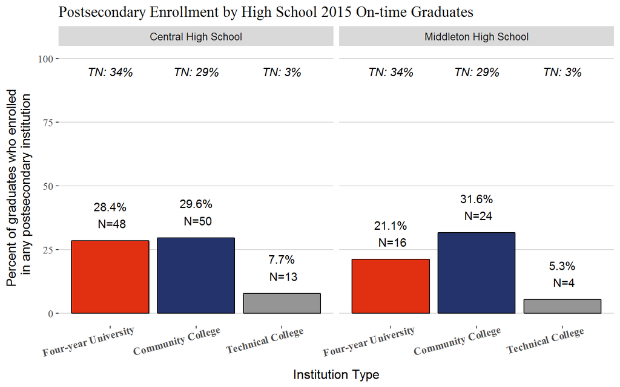

### **Notes**

Use this space to record any thoughts or questions about the overall levels of postsecondary enrollment in your district.

## SECTION II: Postsecondary Enrollment by Subgroup

### Subgroup comparisons

- To what extent do we see overall equitable access by race in the same school to postsecondary institutions?
- Within each school, to what extent are students of different racial backgrounds enrolling in different types of postsecondary institutions (e.g. a higher distribution of one group is enrolling in four-year universities than two year institutions)?
- If your district has more than one school, to what extent do the overall enrollment rates differ across schools in your districts for racial and ethnic groups?
- If your district has more than one school, to what extent do enrollment rates for racial and ethnic subggroups into different types of postecondary institutions differ across schools?
- Given this information, do you feel that all students are receiving the same opportunities in your district?

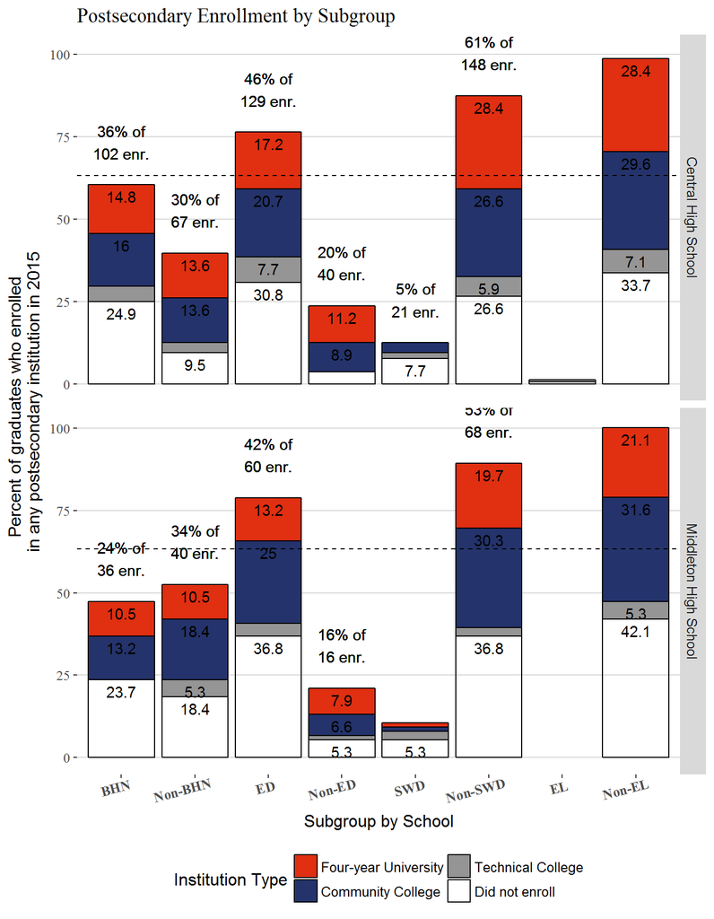

## SECTION III: Postsecondary Enrollment By Academic Achievement

#### Postsecondary Enrollment By ACT Scores

- Consider the distribution of ACT composite scores for the students in your district.
- Is the percent of students who did not enroll in a postsecondary institution higher than you expected?
- To what extent do the ACT scores relate to the type of postsecondary institution into which a student enrolled?

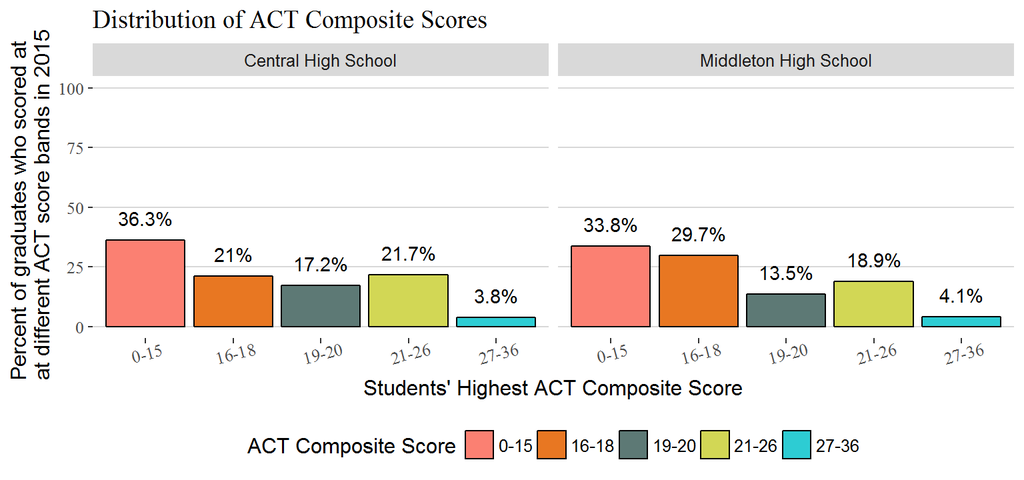

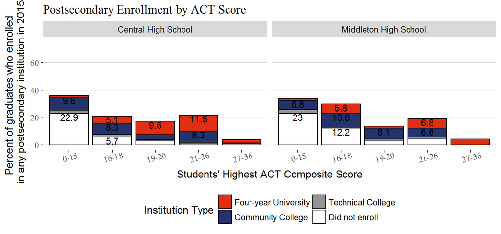

- Other possible questions
  - To what extent does the relationship between ACT scores and postsecondary enrollment in your district differ from the state average?
  - To what extent does the relationship between ACT scores and the type of postsecondary institution where students are enrolling in your district differ from the state average?

## Section IV: Postsecondary Enrollment By Coursework

#### Access to EPSOs (Early Postsecondary Opportunities)

- To what extent do all students have access to rigorous coursework that can result in early postsecondary credit in the 2011 graduating cohort who graduated in spring 2015?
- What types of EPSOs are offered in your schools?
- How are students placed into EPSOs in your schools?

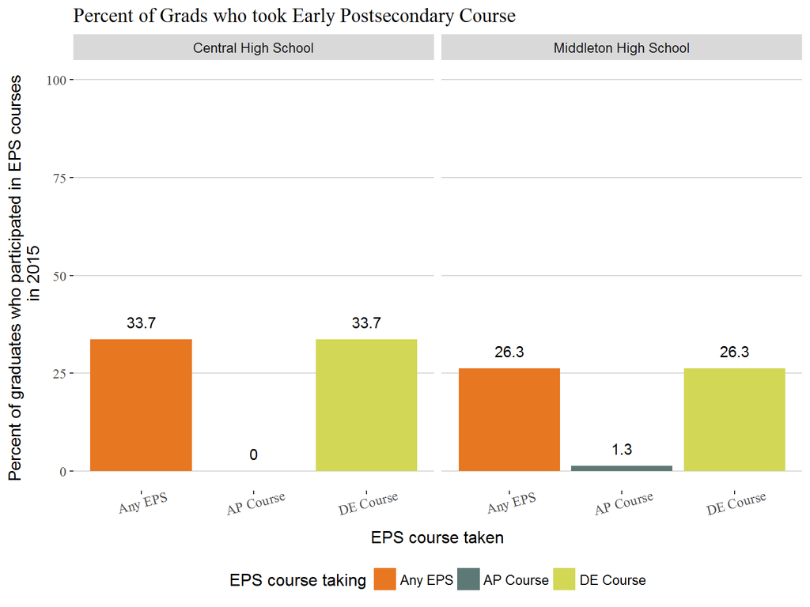

#### EPS Access by subgroup

- To what extent does access to EPS courses differ by student race?

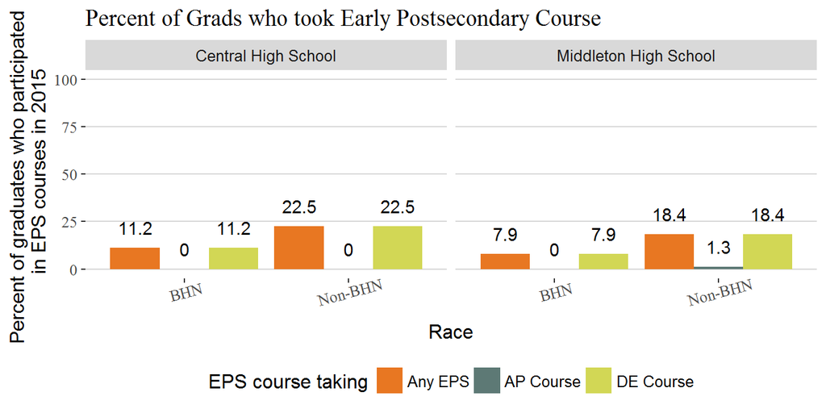

- To what extent does access to EPSOs differ by the economic disadvantage status of the students?

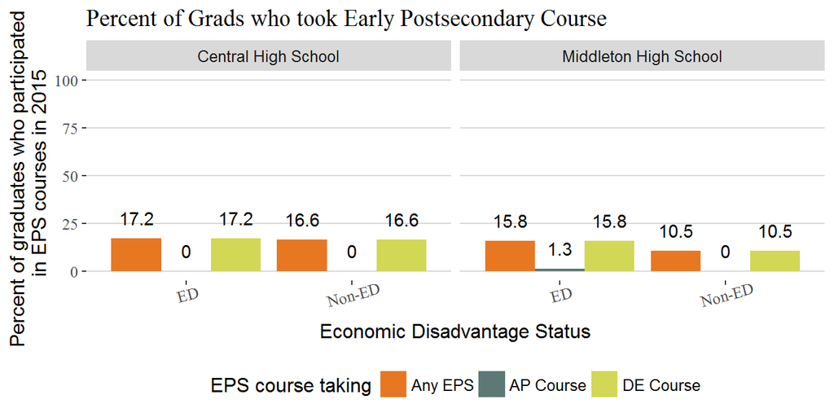

#### Postseconary Enrollment for EPS Students

- To what extent do students who took EPS courses enroll in a postsecondary institution?
- To what extent do students who took EPS courses enroll in different types of postsecondary institutions?

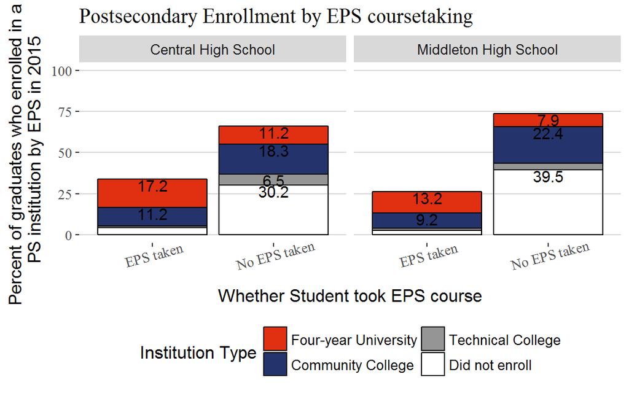

- To what extent do Economically Disadvantaged students benefit from EPS courses?

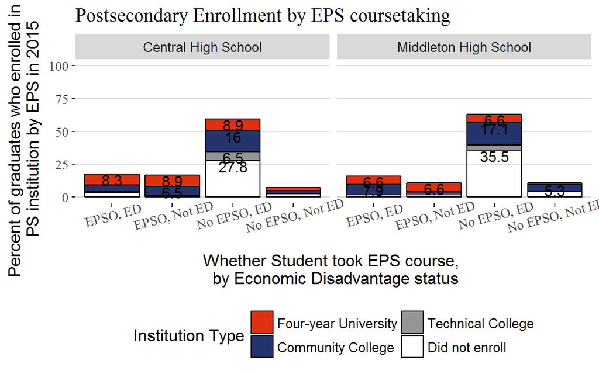

## Persistence of all students (Not included in initial release)

# APPENDICES

CCTE Team would develop a series of strategies that would target potential stories that would arise from the data

## Appendix C: Business Rules/Data Sources

When we release data, we have to make sure that we clear set of business rules defined.

# Preliminary timeline

### April 20

Based on CORE feedback, we would put together the final mock-ups to share within the department, to THEC, TOSS, etc Bring in communications team for state level communication plans

### May 1

Integration of strategies

### May 15

Continuing TDOE feedback, CORE Feedback and maybe trusted partners Data Validated

### June

To Directors for feedback, Validation period begins with CORE Data Analysts and CTE Consultants

June 30: Deadline for receiving 2016 enrollment data from P20 for SSC reports

### June/July

CORE Data analysts set up meetings with district teams CTE trainings

### August

Superintendent Study Council Preparation